# 6_2_1函数类型

## 练习题

请尝试完成以下练习：

1. 定义一个函数，输入国家名，输出该国家的首都（可以用条件语句）。
2. 定义一个函数，判断输入的历史人物是否出现在指定列表中。
3. 使用 lambda 函数将一组书名按字符数排序。
4. 定义一个返回当前课程信息的无参有返回值函数。

### 5 随机函数

Python 提供 `random` 模块用于生成随机数、抽样、洗牌等操作，常用于模拟、抽签、问卷等场景。

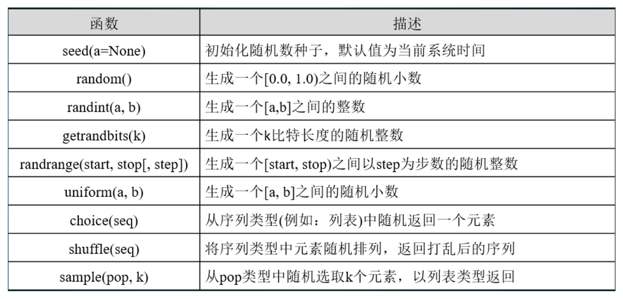

```python
import random

# 生成 1 到 100 的随机整数
# print("随机整数：", random.randint(1, 100))

# 从列表中随机抽取一个文豪名字
authors = ["鲁迅", "胡适", "老舍", "冰心", "沈从文"]
#print("随机抽取一位文豪：", random.choice(authors))

# # # 模拟抽签（不重复地抽3位）
print("抽签选出3位演讲代表：", random.sample(authors, 3))
```

```
抽签选出3位演讲代表： ['鲁迅', '胡适', '老舍']
```

```python
### 示例：生成今日文艺学习任务

tasks = ["阅读一首诗", "抄写一段散文", "观看纪录片", "整理读书笔记", "欣赏一幅画"]
task = random.choice(tasks)
print("今日文艺学习任务：", task)
```

```
今日文艺学习任务： 阅读一首诗
```

### 练习随机点名，抽签

场景：课堂上，老师需要随机选一名学生回答问题

使用方法：

老师运行这个程序

程序会随机显示一个学生名字

被选中的学生站起来回答问题

```python
import random

# 班级学生名单
students = ["小明", "小红", "小刚", "小丽", "小强"]

# 随机抽一名学生回答问题
print("今天回答问题的是:", random.choice(students))
```

```
今天回答问题的是: 小明
```

```python
import random  # 导入随机模块

# 学生名单（可以自行添加或修改）
students = ["小明", "小红", "小刚", "小芳", "小李"]

student = random.choice(students)  # 从学生名单中随机选择一个
print(f"👏 被点到的同学是：{student}")
```

```
👏 被点到的同学是：小红
```

```python
import random  # 导入随机模块

# 学生名单（可以自行添加或修改）
students = ["小明", "小红", "小刚", "小芳", "小李"]

# 签的内容
draws = ["今天回答问题", "下次带作业", "表现优秀，奖励一颗星", "提个问题给大家", "下次做小组长"]

# 随机点名
def random_name():
    student = random.choice(students)  # 从学生名单中随机选择一个
    print(f"👏 被点到的同学是：{student}")

# 抽签
def random_draw():
    draw = random.choice(draws)  # 从签中随机抽取
    print(f"🎲 抽签结果是：{draw}")

# 主程序
print("------欢迎使用随机点名与抽签系统------")
random_name()
random_draw()
```

[output not shown]

### 6 时间函数

Python 中处理时间的常用模块是 `time` 和 `datetime`。

| 函数 | 描述 |
| --- | --- |
| `time()` | 返回当前时间的时间戳（1970纪元后经过的浮点秒数） |
| `ctime([secs])` | 将时间戳转换为可读字符串 |
| `asctime([t])` | 将时间元组转换为可读字符串 |
| `localtime([secs])` | 将时间戳转换为本地时间的时间元组 |
| `gmtime([secs])` | 将时间戳转换为UTC时间的时间元组 |
| `mktime(t)` | 将时间元组转换为时间戳 |
| `sleep(secs)` | 推迟执行线程的时间，单位为秒 |
| `strftime(format[, t])` | 将时间元组格式化为字符串 |
| `strptime(string, format)` | 将字符串解析为时间元组 |

## Python `datetime` 模块常用函数与方法表

| 函数 / 方法 | 描述 |
| --- | --- |
| `datetime.datetime.now()` | 获取当前本地日期和时间，返回 `datetime` 对象 |
| `datetime.datetime.utcnow()` | 获取当前 UTC 日期和时间，返回 `datetime` 对象 |
| `datetime.datetime.today()` | 获取当前本地日期和时间，等同于 `now()` |
| `datetime.datetime.fromtimestamp(ts)` | 将时间戳转换为本地时间对应的 `datetime` 对象 |
| `datetime.datetime.utcfromtimestamp(ts)` | 将时间戳转换为 UTC 时间对应的 `datetime` 对象 |
| `datetime.datetime.strptime(date_str, format)` | 将字符串按指定格式转换为 `datetime` 对象 |
| `datetime.datetime.strftime(format)` | 将 `datetime` 对象格式化为字符串 |
| `datetime.date.today()` | 获取当前日期（年月日），返回 `date` 对象 |
| `datetime.time()` | 创建时间对象（小时、分钟、秒、微秒） |
| `datetime.timedelta(days=0, seconds=0, ...)` | 用于表示时间间隔，可进行加减运算 |

```python
import time
from datetime import datetime

# 当前时间戳
print("当前时间戳：", time.time())

# # 当前本地时间（格式化）
print("当前本地时间：", time.strftime("%Y-%m-%d %H:%M:%S"))

# # 获取当前具体时间对象
now = datetime.now()
print("当前年份：", now.year)
print("当前月份：", now.month)
print("当前日期：", now.day)
```

```
当前时间戳： 1745398994.3246825
当前本地时间： 2025-04-23 17:03:14
当前年份： 2025
当前月份： 4
当前日期： 23
```

```python
from datetime import datetime, timedelta

now = datetime.now()
print("当前时间：", now)

dt = datetime.strptime("2025-04-07 15:30", "%Y-%m-%d %H:%M")
print("字符串转时间对象：", dt)

future = now + timedelta(days=7)
print("7天后的时间：", future)

formatted = now.strftime("%Y年%m月%d日 %H:%M:%S")
print("格式化时间：", formatted)
```

```
当前时间： 2025-04-23 17:03:32.251077
字符串转时间对象： 2025-04-07 15:30:00
7天后的时间： 2025-04-30 17:03:32.251077
格式化时间： 2025年04月23日 17:03:32
```

```python
### 示例：记录阅读文章所用时间
```

```python
# 模拟记录阅读文章所花的时间
start = time.time()
input("请按回车键开始阅读《论语》片段...")
input("阅读完毕后请按回车键...")
end = time.time()

duration = end - start
print(f"你大约阅读了 {duration:.2f} 秒。")
```

## 练习题

请完成以下练习，巩固时间函数与随机函数的使用：

1. 使用 `time` 模块编写一个函数，记录你朗读一段文字所用的时间。
2. 使用 `datetime` 获取并打印今天是星期几。
3. 使用 `random` 模拟从5位作者中随机选出2位进行对谈。
4. 自定义一个“文艺任务生成器”，随机选择主题、形式、时间段组合成一句完整的学习建议。

```python
import time

# 1. 朗读计时器
print("===== 朗读计时器 =====")
input("请准备好朗读以下文字，按回车键开始：\n")
text = "Python是一种广泛使用的高级编程语言，以其简洁易读的语法而闻名。"
print(f"请朗读以下文字：\n{text}")

start_time = time.time()
input("朗读完成后按回车键结束计时：")
end_time = time.time()

duration = end_time - start_time
print(f"你朗读这段文字用了 {duration:.2f} 秒")
```

```python
#import time
import datetime
# 2. 获取今天是星期几
print("\n===== 今天是星期几 =====")
today = datetime.datetime.now()
weekdays = ["星期一", "星期二", "星期三", "星期四", "星期五", "星期六", "星期日"]
print(f"今天是 {weekdays[today.weekday()]}")
```

[output not shown]

```python
# 3.从5位作者中随机选出2位进行对谈
import random
print("\n===== 随机选择两位作者 =====")
authors = ["鲁迅", "老舍", "巴金", "茅盾", "沈从文"]
selected = random.sample(authors, 2)
print(f"随机选出的两位作者是：{selected[0]} 和 {selected[1]}")
```

```
===== 随机选择两位作者 =====
随机选出的两位作者是：巴金 和 鲁迅
```

```python
# 4. 文艺任务生成器
print("\n===== 文艺任务生成器 =====")
themes = ["春天", "城市", "童年", "爱情", "孤独"]
forms = ["写一首诗", "画一幅画", "创作一篇短文", "拍一组照片", "写一首歌"]
times = ["清晨", "午后", "黄昏", "深夜", "周末"]

theme = random.choice(themes)
form = random.choice(forms)
time_period = random.choice(times)

print(f"学习建议：在{time_period}，尝试用{form}来表达'{theme}'这个主题")
```

```
===== 文艺任务生成器 =====
学习建议：在清晨，尝试用创作一篇短文来表达'童年'这个主题
```